# Mapping NYC rodent sightings

Kate Newton

31 August 2018

# Load libraries

```r
library(tidyverse)
library(ggplot2)
library(dplyr)
library(lubridate)
library(stringr)
```

# Import rodent data

Import New York City data on rodent-related 311 complaints between 2010 and August 2018. The full data is available at the following link but is a 20GB file, so the zipped file is data downloaded after applying a ‘Complaint Type’ filter for ‘Rodent’ https://nycopendata.socrata.com/Social-Services/311-Service-Requests-from-2010-to-Present/erm2-nwe9

```r
unzip("Service_Requests_from_2010_to_Present_rodents.zip", "Service_Requests_from_2010_to_Present_rodents.csv")

complaints <- read.csv("Service_Requests_from_2010_to_Present_rodents.csv", stringsAsFactors = F)
```

# Import geographic data

```r
library(sf)
library(censusapi)
library(tigris)
options(tigris_class = "sf")
```

Creating two geographic dataframes - one just for New York and the other for all five boroughs. Final visualisations for this project focused on Manhattan but code supplied for both options.

```r
nyc <- tracts(state = "NY", county = "New York", cb=T)
five_boroughs <- rbind_tigris(
  tracts(state = "NY", county = "New York", cb = TRUE),
  tracts(state = "NY", county = "Kings", cb = TRUE),
  tracts(state = "NY", county = "Bronx", cb = TRUE),
  tracts(state = "NY", county = "Richmond", cb = TRUE),
  tracts(state = "NY", county = "Queens", cb = TRUE))
```

# Cleaning dataframe containing 311 data

```r
rodents <- complaints %>%
  select(Unique.Key, Created.Date, Descriptor, Location.Type, Incident.Zip,
         Incident.Address, Street.Name, City, BBL, Borough, Latitude,
         Longitude, Location) %>%
  filter(Descriptor %in% c("Rat Sighting", "Mouse Sighting"))
```

Get rid of any NAs in the Longitude and Latitude columns so it doesn’t throw errors when doing spatial joins later

```r
rodents_complete <- rodents[complete.cases(rodents[ , 11:12]),]
```

```r
# Tidy up date information (not used in final visualisation)

rodents_complete$date <- mdy_hms(rodents_complete$Created.Date)
rodents_complete$year <- year(rodents_complete$date)
```

# Charting rodent sightings by borough

First remove any sightings where the borough is listed as ‘Unspecified’ and then group by borough to get the total.

```r
rodents_boroughs <- rodents_complete %>%
  filter(Borough!="Unspecified") %>%
  group_by(Borough) %>%
  summarize(total=n())
```

Next, chart by borough, with browns and grays for the bars to keep with the rodent theme

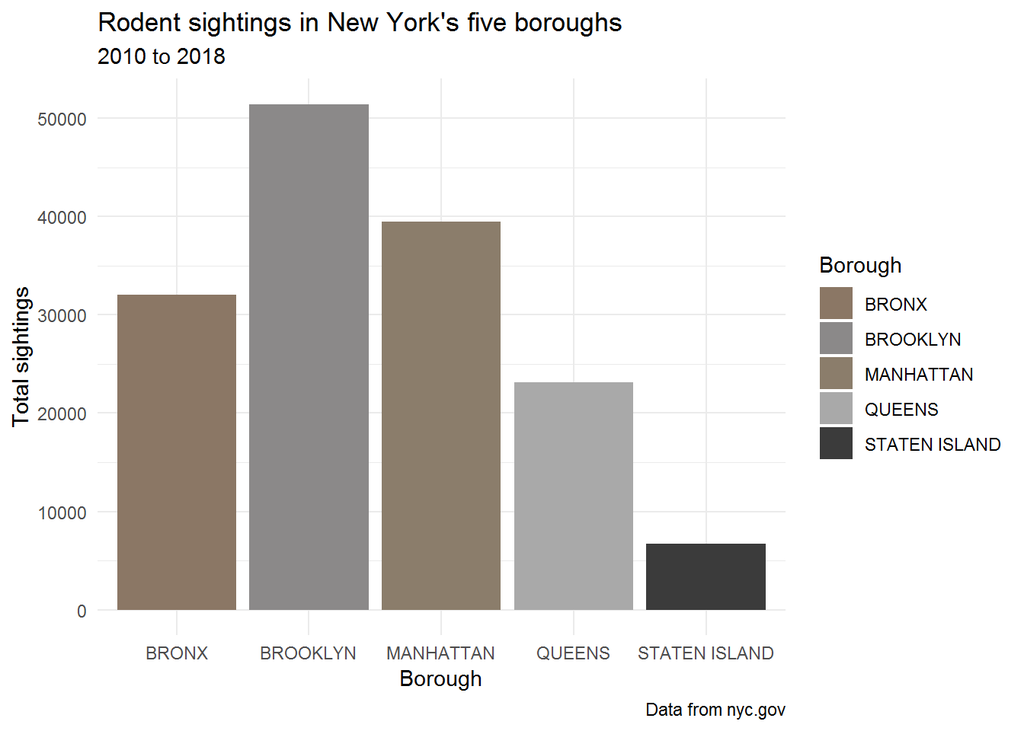

```r
ggplot(rodents_boroughs, aes(x=Borough, y=total, fill=Borough)) +
  geom_bar(stat="identity") +
  scale_fill_manual("Borough",
                    values = c("BRONX" = "peachpuff4", "BROOKLYN" = "snow4", "MANHATTAN" = "bisque4",
                               "QUEENS" = "darkgrey", "STATEN ISLAND" = "grey23")) +
  theme_minimal() +
  labs(x="Borough", y="Total sightings",
       title = "Rodent sightings in New York's five boroughs",
       subtitle = "2010 to 2018",
       caption = "Data from nyc.gov")
```

# Create spatial data for mapping

```r
# Add spatial data to dataframe
rodents_spatial <- rodents_complete %>% st_as_sf(coords=c("Longitude", "Latitude"),
                            crs = "+proj=longlat") %>%
  st_transform(crs=st_crs(five_boroughs))
```

```r
# Map points to Census tracts

rodent_points <- st_join(five_boroughs, rodents_spatial, left=T)
```

```
## although coordinates are longitude/latitude, st_intersects assumes that they are planar
```

```r
manhattan_points <- st_join(nyc, rodents_spatial, left=T)
```

```
## although coordinates are longitude/latitude, st_intersects assumes that they are planar
```

```r
# Create summarised data to map

rodent_tracts <- rodent_points %>%
  group_by(GEOID) %>%
  summarise(total=n())

manhattan_tracts <- manhattan_points %>%
  group_by(GEOID) %>%
  summarise(total=n())
```

# Create geographic data for map border

```r
boroughs <- counties(state="NY", cb=T)
borough_borders <- filter(boroughs, NAME %in% c("New York", "Kings", "Bronx", "Richmond", "Queens"))
manhattan_border <- filter(boroughs, NAME=="New York")
```

# Where is Pizza Rat?

Okay, okay, so this isn’t in the data, but just for fun I decided to map Pizza Rat, of internet meme fame. He was spotted in 2015 in the 1st Ave subway station in East Village, so I made him his own mini dataframe.

```r
pizza_rat <- data.frame(name = "Pizza Rat (2015)", Longitude = -73.982272, Latitude = 40.732955)
```

# Mapping the data

You can create various iterations of this map, faceted by year etc, but this particular code creates a choropleth of all rodent sightings in Manhattan between 2010 and 2018.

It’s got a custom rodent-coloured colour palette and an arrow marker and label for Pizza Rat (mapped as a single dot point in a separate layer).

The colour scale is set with the maximum just above the maximum total sightings for an individual Census tract (found using `max(manhattan_tracts$total)`) and the midpoint halfway between that and zero.

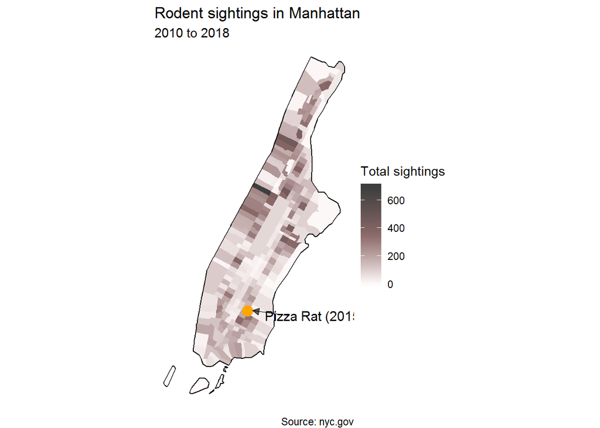

```r
ggplot(manhattan_tracts) +
  geom_sf(aes(fill = total), color=NA) +
  coord_sf(datum=NA) +
  geom_sf(data=manhattan_border, fill=NA, color="black") +
  labs(title = "Rodent sightings in Manhattan",
       subtitle = "2010 to 2018",
       caption = "Source: nyc.gov",
       fill = "Total sightings") +
  scale_fill_gradient2(low = "snow1", mid = "rosybrown4",
                       high = "grey24", midpoint=350, limits=c(0, 700)) +
  geom_point(data=pizza_rat, aes(x=Longitude, y=Latitude), color="orange", size=4) +
  annotate("text", x=-73.93, y=40.73, label="Pizza Rat (2015)", size=4) +
  annotate("segment", x=-73.95, xend=-73.978, y=40.73, yend=40.733,
           colour = "black", size=0.5, alpha=0.6,
           arrow=arrow(length=unit(0.2, "cm"), type="closed")) +
  theme_void() +
  theme(panel.grid.major = element_line(colour = 'transparent'))
```